# Introduction to R: Basic data manipulation and plotting

Kodi Weatherholtz

February 3, 2016 BCS 207

# Goals

By the end of this tutorial, you should be able to:

1. Read data into R
2. Perform basic data manipulations
   - summarize data
   - (cross) tabulation
   - means + SDs
   - subsetting
3. Create simple plots to visualize data

# Caveats

- In R (and any programming language), there are many ways to achieve the same result. Methods differ in **efficiency**, **elegance**, **intuitiveness**, **simplicity**.
- We want you to *quickly gain working knowledge* of data wrangling in R. Therefore, we prioritize **simplicity**.

# Basic R commands

# Variable assignment

The “<-” symbol is used to assign data to a variable name

```r
# set x equal to the number 1
x <- 1
print(x)
```

```
[1] 1
```

```r
x # by default, if we call an object, R applies the print function
```

```
[1] 1
```

```r
class(x)
```

```
[1] "numeric"
```

```r
length(x)
```

```
[1] 1
```

# Variable assignment, cont’d

```r
# assign a character string to y
y <- "Zombies like brains."
y
```

```
[1] "Zombies like brains."
```

```r
class(y)
```

```
[1] "character"
```

```r
length(y) # Why is the length 1??
```

```
[1] 1
```

```r
# set z equal to the Boolean value FALSE
z <- FALSE
class(z)
```

```
[1] "logical"
```

# Vectors

```r
# set x equal to a vector of numbers
x <- c(1, 2, 3)
x
```

```
[1] 1 2 3
```

```r
# change x. Set it equal to the integers from 12 to 23.
x <- c(12:23)
x
```

```
 [1] 12 13 14 15 16 17 18 19 20 21 22 23
```

```r
# locate the 7th element of x
x[7]
```

```
[1] 18
```

# Basic operations on vectors

```r
x
```

```
 [1] 12 13 14 15 16 17 18 19 20 21 22 23
```

```r
# calculate the mean of x
mean(x)
```

```
[1] 17.5
```

```r
# Multiply each element of x by 8
x * 8
```

```
 [1]  96 104 112 120 128 136 144 152 160 168 176 184
```

```r
# Your turn... What does this do?
x + x
```

```
 [1] 24 26 28 30 32 34 36 38 40 42 44 46
```

# Reading data into R

# Data formats

R can import data that is stored in a wide variety of formats, including complex formats: **JSON**, **XML**, **Excel workbooks**, **SPSS data files**

The easiest format to import is flat, character-delimited text files: **tab-delimited**, **comma-separated** (CSV)

# Character-separated files

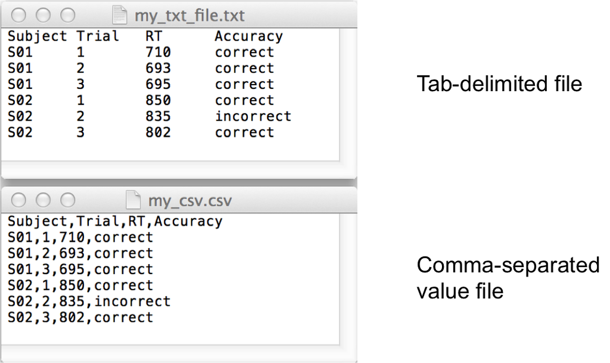

# Import tab-delimited data

- The first step when importing data is to tell R where to look
- Typically this is done by setting the **working directory**

```r
# Set working directory
setwd("/Users/kweatherholtz/Desktop/BCS207/data")

# Alternatively, use the 'relative' path
# setwd(~/Desktop/BCS207/data)

# Read in a tab-delimited file
# (and interpret the first row as a header row)
df1 <- read.table(file = "my_txt_file.txt",
                  header = TRUE,
                  sep = "\t") # note: "\t" means tab

print(df1)
```

```
  Subject Trial  RT  Accuracy
1     S01     1 710   correct
2     S01     2 693   correct
3     S01     3 695   correct
4     S02     1 850   correct
5     S02     2 835 incorrect
6     S02     3 802   correct
```

# Import comma-separated data

```r
# Read in a tab-delimited file.
# Note that here we are using the RELATIVE path to the data file
df2 <- read.table(file = "~/Desktop/BCS207/data/my_csv.csv",
                  header = TRUE,
                  sep = ",")

print(df2)
```

```
  Subject Trial  RT  Accuracy
1     S01     1 710   correct
2     S01     2 693   correct
3     S01     3 695   correct
4     S02     1 850   correct
5     S02     2 835 incorrect
6     S02     3 802   correct
```

# Your turn…

1. Assume you have the file below in your working directory. How would you read this file into R?

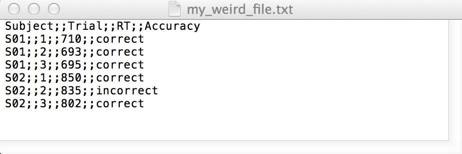

- For more information about reading data, see the manual:

```r
help(read.table)
```

# Basic data manipulations: Tabulation and cross-tabulation

Let’s look at some real world psycholinguistic data!

```r
# Step 1: install the 'languageR' package by running the line below
# install.packages('langaugeR')

# Step 2: load the 'languageR' package
library(languageR)

data(lexdec) # a lexical decision data set from languageR
head(lexdec) # print the first few rows of a data frame (default = 6)
```

```
  Subject       RT Trial Sex NativeLanguage Correct PrevType PrevCorrect
1      A1 6.340359    23   F        English correct     word     correct
2      A1 6.308098    27   F        English correct  nonword     correct
3      A1 6.349139    29   F        English correct  nonword     correct
4      A1 6.186209    30   F        English correct     word     correct
5      A1 6.025866    32   F        English correct  nonword     correct
6      A1 6.180017    33   F        English correct     word     correct
        Word Frequency FamilySize SynsetCount Length  Class FreqSingular
1        owl  4.859812  1.3862944   0.6931472      3 animal           54
2       mole  4.605170  1.0986123   1.9459101      4 animal           69
3     cherry  4.997212  0.6931472   1.6094379      6  plant           83
4       pear  4.727388  0.0000000   1.0986123      4  plant           44
5        dog  7.667626  3.1354942   2.0794415      3 animal         1233
6 blackberry  4.060443  0.6931472   1.3862944     10  plant           26
  FreqPlural DerivEntropy Complex      rInfl meanRT SubjFreq meanSize
1         74       0.7912 simplex -0.3101549 6.3582     3.12   3.4758
2         30       0.6968 simplex  0.8145080 6.4150     2.40   2.9999
3         49       0.4754 simplex  0.5187938 6.3426     3.88   1.6278
4         68       0.0000 simplex -0.4274440 6.3353     4.52   1.9908
5        828       1.2129 simplex  0.3977961 6.2956     6.04   4.6429
6         31       0.3492 complex -0.1698990 6.3959     3.28   1.5831
  meanWeight      BNCw      BNCc       BNCd BNCcRatio BNCdRatio
1     3.1806 12.057065  0.000000   6.175602  0.000000  0.512198
2     2.6112  5.738806  4.062251   2.850278  0.707856  0.496667
3     1.2081  5.716520  3.249801  12.588727  0.568493  2.202166
4     1.6114  2.050370  1.462410   7.363218  0.713242  3.591166
5     4.5167 74.838494 50.859385 241.561040  0.679589  3.227765
6     1.1365  1.270338  0.162490   1.187616  0.127911  0.934882
```

# A brief note about the internal structure of data objects in R

`str()` allows us to view the ‘structure’ of a data object

```r
str(lexdec)
```

```
'data.frame':   1659 obs. of  28 variables:
 $ Subject       : Factor w/ 21 levels "A1","A2","A3",..: 1 1 1 1 1 1 1 1 1 1 ...
 $ RT            : num  6.34 6.31 6.35 6.19 6.03 ...
 $ Trial         : int  23 27 29 30 32 33 34 38 41 42 ...
 $ Sex           : Factor w/ 2 levels "F","M": 1 1 1 1 1 1 1 1 1 1 ...
 $ NativeLanguage: Factor w/ 2 levels "English","Other": 1 1 1 1 1 1 1 1 1 1 ...
 $ Correct       : Factor w/ 2 levels "correct","incorrect": 1 1 1 1 1 1 1 1 1 1 ...
 $ PrevType      : Factor w/ 2 levels "nonword","word": 2 1 1 2 1 2 2 1 1 2 ...
 $ PrevCorrect   : Factor w/ 2 levels "correct","incorrect": 1 1 1 1 1 1 1 1 1 1 ...
 $ Word          : Factor w/ 79 levels "almond","ant",..: 55 47 20 58 25 12 71 69 62 1 ...
 $ Frequency     : num  4.86 4.61 5 4.73 7.67 ...
 $ FamilySize    : num  1.386 1.099 0.693 0 3.135 ...
 $ SynsetCount   : num  0.693 1.946 1.609 1.099 2.079 ...
 $ Length        : int  3 4 6 4 3 10 10 8 6 6 ...
 $ Class         : Factor w/ 2 levels "animal","plant": 1 1 2 2 1 2 2 1 2 2 ...
 $ FreqSingular  : int  54 69 83 44 1233 26 50 63 11 24 ...
 $ FreqPlural    : int  74 30 49 68 828 31 65 47 9 42 ...
 $ DerivEntropy  : num  0.791 0.697 0.475 0 1.213 ...
 $ Complex       : Factor w/ 2 levels "complex","simplex": 2 2 2 2 2 1 1 2 2 2 ...
 $ rInfl         : num  -0.31 0.815 0.519 -0.427 0.398 ...
 $ meanRT        : num  6.36 6.42 6.34 6.34 6.3 ...
 $ SubjFreq      : num  3.12 2.4 3.88 4.52 6.04 3.28 5.04 2.8 3.12 3.72 ...
 $ meanSize      : num  3.48 3 1.63 1.99 4.64 ...
 $ meanWeight    : num  3.18 2.61 1.21 1.61 4.52 ...
 $ BNCw          : num  12.06 5.74 5.72 2.05 74.84 ...
 $ BNCc          : num  0 4.06 3.25 1.46 50.86 ...
 $ BNCd          : num  6.18 2.85 12.59 7.36 241.56 ...
 $ BNCcRatio     : num  0 0.708 0.568 0.713 0.68 ...
 $ BNCdRatio     : num  0.512 0.497 2.202 3.591 3.228 ...
```

# High-level descriptive statistics

The `summary()` function, when applied to a data frame, provides descriptive statistics about each variable in the data.

```r
summary(lexdec)
```

```
    Subject           RT            Trial     Sex      NativeLanguage
 A1     :  79   Min.   :5.829   Min.   : 23   F:1106   English:948
 A2     :  79   1st Qu.:6.215   1st Qu.: 64   M: 553   Other  :711
 A3     :  79   Median :6.346   Median :106
 C      :  79   Mean   :6.385   Mean   :105
 D      :  79   3rd Qu.:6.502   3rd Qu.:146
 I      :  79   Max.   :7.587   Max.   :185
 (Other):1185
      Correct        PrevType      PrevCorrect          Word
 correct  :1594   nonword:855   correct  :1542   almond   :  21
 incorrect:  65   word   :804   incorrect: 117   ant      :  21
                                                 apple    :  21
                                                 apricot  :  21
                                                 asparagus:  21
                                                 avocado  :  21
                                                 (Other)  :1533
   Frequency       FamilySize      SynsetCount         Length
 Min.   :1.792   Min.   :0.0000   Min.   :0.6931   Min.   : 3.000
 1st Qu.:3.951   1st Qu.:0.0000   1st Qu.:1.0986   1st Qu.: 5.000
 Median :4.754   Median :0.0000   Median :1.0986   Median : 6.000
 Mean   :4.751   Mean   :0.7028   Mean   :1.3154   Mean   : 5.911
 3rd Qu.:5.652   3rd Qu.:1.0986   3rd Qu.:1.6094   3rd Qu.: 7.000
 Max.   :7.772   Max.   :3.3322   Max.   :2.3026   Max.   :10.000

    Class      FreqSingular      FreqPlural     DerivEntropy
 animal:924   Min.   :   4.0   Min.   :  0.0   Min.   :0.0000
 plant :735   1st Qu.:  23.0   1st Qu.: 19.0   1st Qu.:0.0000
              Median :  69.0   Median : 49.0   Median :0.0370
              Mean   : 132.1   Mean   :109.7   Mean   :0.3856
              3rd Qu.: 146.0   3rd Qu.:132.0   3rd Qu.:0.6845
              Max.   :1518.0   Max.   :854.0   Max.   :2.2641

    Complex         rInfl             meanRT         SubjFreq
 complex: 210   Min.   :-1.3437   Min.   :6.245   Min.   :2.000
 simplex:1449   1st Qu.:-0.3023   1st Qu.:6.322   1st Qu.:3.160
                Median : 0.1900   Median :6.364   Median :3.880
                Mean   : 0.2845   Mean   :6.379   Mean   :3.911
                3rd Qu.: 0.6385   3rd Qu.:6.420   3rd Qu.:4.680
                Max.   : 4.4427   Max.   :6.621   Max.   :6.040

    meanSize       meanWeight          BNCw               BNCc
 Min.   :1.323   Min.   :0.8244   Min.   : 0.02229   Min.   : 0.0000
 1st Qu.:1.890   1st Qu.:1.4590   1st Qu.: 1.64921   1st Qu.: 0.1625
 Median :3.099   Median :2.7558   Median : 3.32071   Median : 0.6500
 Mean   :2.891   Mean   :2.5516   Mean   : 7.37800   Mean   : 5.0351
 3rd Qu.:3.711   3rd Qu.:3.4178   3rd Qu.: 7.10943   3rd Qu.: 2.9248
 Max.   :4.819   Max.   :4.7138   Max.   :79.17324   Max.   :83.1949

      BNCd           BNCcRatio         BNCdRatio
 Min.   :  0.000   Min.   :0.00000   Min.   :0.0000
 1st Qu.:  1.188   1st Qu.:0.09673   1st Qu.:0.5551
 Median :  3.800   Median :0.27341   Median :0.9349
 Mean   : 12.995   Mean   :0.45834   Mean   :1.5428
 3rd Qu.: 10.451   3rd Qu.:0.55550   3rd Qu.:2.1315
 Max.   :241.561   Max.   :8.29545   Max.   :6.3458
```

# Tabulate data

- **How many observations (data points) do we have for each subject?**
- To find the answer, we simply tabulate the data by subject

```r
table(lexdec$Subject)
```

```
A1 A2 A3  C  D  I  J  K M1 M2  P R1 R2 R3  S T1 T2  V W1 W2  Z
79 79 79 79 79 79 79 79 79 79 79 79 79 79 79 79 79 79 79 79 79
```

# Tabulate data, cont’d.

- **How many males and females participated in this exp?**
- Again, this is a simple tabulation problem

```r
# The following line of code tells us the total
# number of observations from females vs. males.
table(lexdec$Sex)
```

```
   F    M
1106  553
```

```r
# Since we already know that each subject provided the same number
# of observations (79), we can identify the number of female vs. male
# participants by dividing each cell in the table above by 79.
table(lexdec$Sex) / 79
```

```
 F  M
14  7
```

# Cross-tabulation

- **How many times did each subject judge each class of words (animal words vs. plant words)?**
- For this, we need to cross-tabulate subject by class

```r
table(lexdec$Subject, lexdec$Class)
```

```
     animal plant
  A1     44    35
  A2     44    35
  A3     44    35
  C      44    35
  D      44    35
  I      44    35
  J      44    35
  K      44    35
  M1     44    35
  M2     44    35
  P      44    35
  R1     44    35
  R2     44    35
  R3     44    35
  S      44    35
  T1     44    35
  T2     44    35
  V      44    35
  W1     44    35
  W2     44    35
  Z      44    35
```

```r
## The following line of code is functionally equivalent,
## but less redundant and a bit easier to read.

# with(lexdec, table(Subject, Class))
```

# Your turn…

1. Given the results of our cross-tabulation, was the manipulation of Class (animal words vs. plant words) a within-subjects or between-subjects manipulation?
   - Within. Each subject judged both classes.
2. How many native speakers vs. non-native speakers participated in the lexdec experiment?
   - native = 12; non-native = 9  
     `table(lexdec$NativeLanguage) / 79`

# Basic data manipulations: Means and standard deviations

# Response times

- How long did it take to make lexical decisions (on average)?
- How variable were subjects’ reponse times?

```r
# calculate the mean response time across all responses
mean(lexdec$RT)
```

```
[1] 6.38509
```

```r
# NOTE: RTs in the pre-packaged lexdec dataset were log-transformed;
# hence, the mean (log) RT of 6.38 is ~590ms
exp(6.38509)
```

```
[1] 592.9381
```

```r
# calculate the standard deviation for RTs
sd(lexdec$RT)
```

```
[1] 0.2415091
```

# Response times for correct responses

We typically only care how long it took subjects to respond correctly. Using the `subset()` function, we can omit errors

```r
# how many incorrect responses are we going to omit
table(lexdec$Correct)
```

```
  correct incorrect
     1594        65
```

```r
# locate ONLY correct responses; save output to a new data frame
correct_resp <- subset(lexdec, Correct == "correct")

# make sure the subset operation worked
table(correct_resp$Correct)
```

```
  correct incorrect
     1594         0
```

```r
# calculate the mean RT from our new data frame
mean(correct_resp$RT)
```

```
[1] 6.383887
```

# Your turn…

1. How many milliseconds did it take on average for non-native English speakers to make a correct lexical decision?
2. How many milliseconds did it take on average for native English speakers to make a correct lexical decision for animal words?

```r
## HINT: when using the subset() function, you can
## chain multiple conditions together using the "&" symbol.

subset(my_data,
       Var1 == "A" & # select only instances of Var1 that equal "A"
       Var2 == "B" &
       Var3 != "C"   # select ALL instances where Var3 DOES NOT EQUAL "C"
       )
```

# How accurate was each participant?

We can use cross-tabulation to calculate by-subject accuracy

```r
# Step 1: calculate the number of correct and incorrect
# responses from each subject. Assign output to a variable
# so we can perform further calculations on this matrix.

xt <- table(lexdec$Subject, lexdec$Correct)
print(xt)
```

```
     correct incorrect
  A1      78         1
  A2      76         3
  A3      79         0
  C       78         1
  D       76         3
  I       79         0
  J       67        12
  K       73         6
  M1      76         3
  M2      75         4
  P       78         1
  R1      74         5
  R2      79         0
  R3      77         2
  S       78         1
  T1      76         3
  T2      72         7
  V       76         3
  W1      76         3
  W2      79         0
  Z       72         7
```

# How accurate was each participant?

```r
# Step 2a: use the rowSums() function to calculate the total
# number of observations per subject (in this case, it should be 79)
rowSums(xt)
```

```
A1 A2 A3  C  D  I  J  K M1 M2  P R1 R2 R3  S T1 T2  V W1 W2  Z
79 79 79 79 79 79 79 79 79 79 79 79 79 79 79 79 79 79 79 79 79
```

```r
# Step2b: divide each cell in the matrix by the corresponding
# row total, which gives us the proportion of correct
# and incorrect responses for each subject
acc.prop <- xt/rowSums(xt)

print(acc.prop)
```

```
        correct  incorrect
  A1 0.98734177 0.01265823
  A2 0.96202532 0.03797468
  A3 1.00000000 0.00000000
  C  0.98734177 0.01265823
  D  0.96202532 0.03797468
  I  1.00000000 0.00000000
  J  0.84810127 0.15189873
  K  0.92405063 0.07594937
  M1 0.96202532 0.03797468
  M2 0.94936709 0.05063291
  P  0.98734177 0.01265823
  R1 0.93670886 0.06329114
  R2 1.00000000 0.00000000
  R3 0.97468354 0.02531646
  S  0.98734177 0.01265823
  T1 0.96202532 0.03797468
  T2 0.91139241 0.08860759
  V  0.96202532 0.03797468
  W1 0.96202532 0.03797468
  W2 1.00000000 0.00000000
  Z  0.91139241 0.08860759
```

# Convert accuracy from proportion to %

```r
# multiply each cell by 100 and round to 1 decimal place
acc.prct <- round(acc.prop * 100, digits = 1)

print(acc.prct)
```

```
     correct incorrect
  A1    98.7       1.3
  A2    96.2       3.8
  A3   100.0       0.0
  C     98.7       1.3
  D     96.2       3.8
  I    100.0       0.0
  J     84.8      15.2
  K     92.4       7.6
  M1    96.2       3.8
  M2    94.9       5.1
  P     98.7       1.3
  R1    93.7       6.3
  R2   100.0       0.0
  R3    97.5       2.5
  S     98.7       1.3
  T1    96.2       3.8
  T2    91.1       8.9
  V     96.2       3.8
  W1    96.2       3.8
  W2   100.0       0.0
  Z     91.1       8.9
```

# Average accuracy *across subjects*

The `colMeans()` function computes the mean of each column in a data object

```r
colMeans(acc.prct)
```

```
  correct incorrect
96.071429  3.928571
```

# Basic data visualization

# Histograms

A histogram is a way to visualize the distribution of data along a single dimension

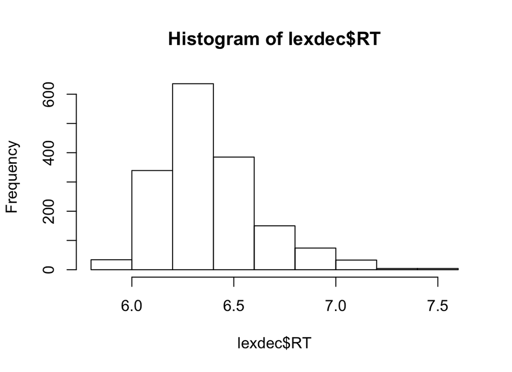

```r
# with the hist() function, you can create a histogram
# by simply specifying the x-axis variable
hist(x = lexdec$RT)
```

# Embellished histogram

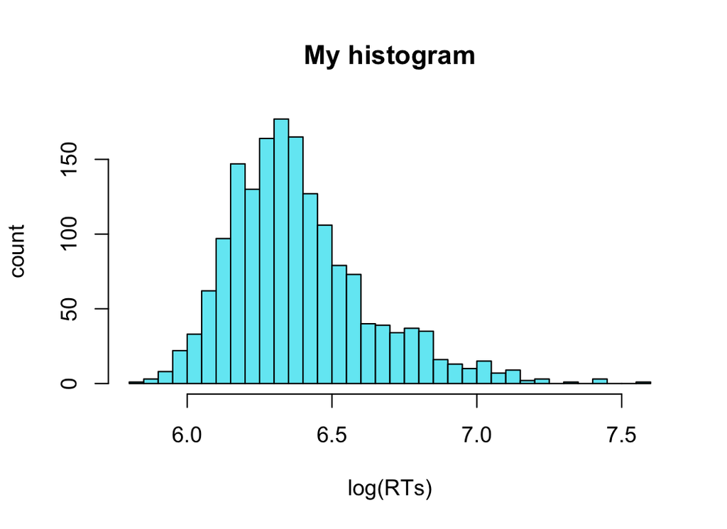

```r
hist(x = lexdec$RT,
     col = "#71e9f4",       # change bar color using HexDec values
     # col = "red",
     xlab = "log(RTs)",     # change x-axis label
     ylab = "count",        # change y-axis label
     main = "My histogram", # change plot title
     breaks = 30            # create 30 break points (i.e., smaller bins)
     )
```

# Scatterplot ( XY plot )

A scatterplot is a way to visualize the relationship between two continuous variables: *does change along the x-axis predict change along the y-axis?*

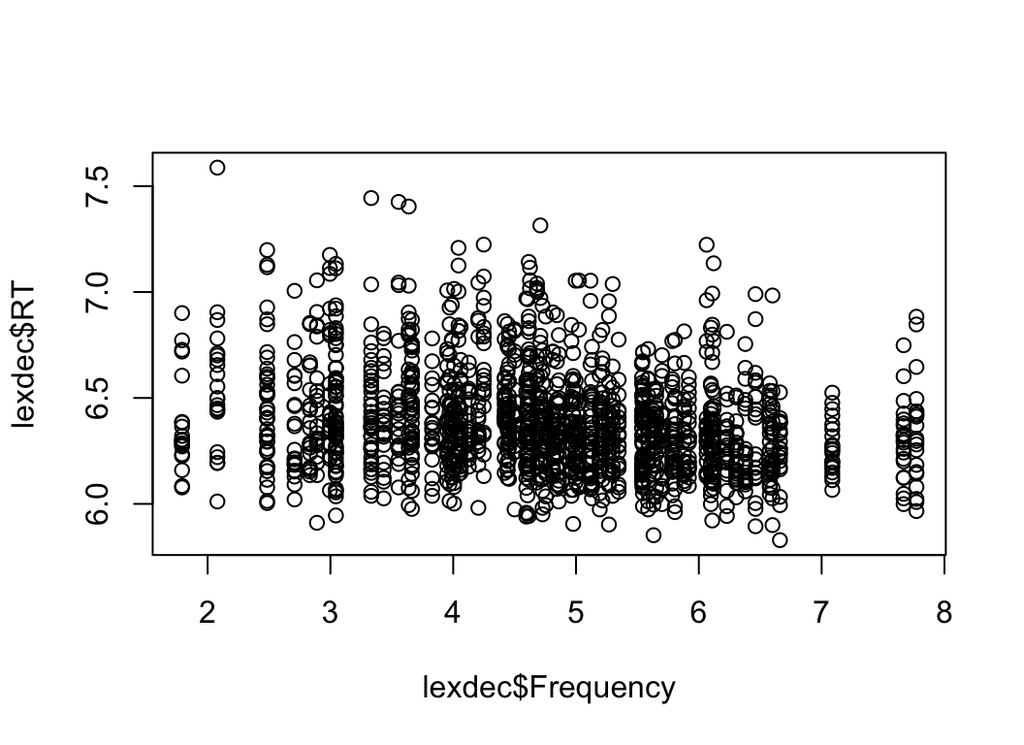

```r
plot(x = lexdec$Frequency, y = lexdec$RT)
```

# Embellished scatterplot

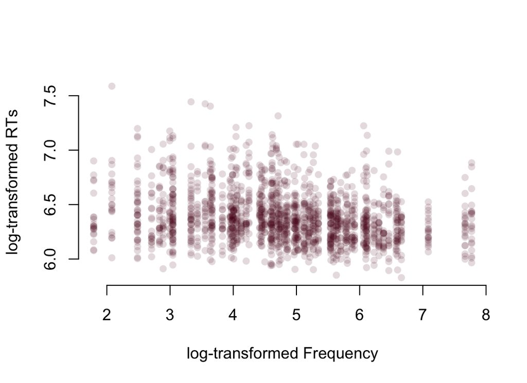

```r
plot(x = lexdec$Frequency, y = lexdec$RT,
     pch = 16, # change the plot character (i.e., symbol)
     col=rgb(red = 0.35, green = 0, blue = 0.1,
             alpha = 0.15), # add alpha transparency
     xlab = "log-transformed Frequency",
     ylab = "log-transformed RTs",
     frame.plot = FALSE # remove the frame around the plot
     )
```

# Your turn…

1. Make a scatterplot to show whether an increase in **FamilySize** appears to predict a change (increase or decrease) in **RTs**.
2. Make a scatterplot to show whether an increase in **Length** appears to predict a change in **RTs**.
3. Reason about the directionality of these effect. Why might we expect a change in this direction?

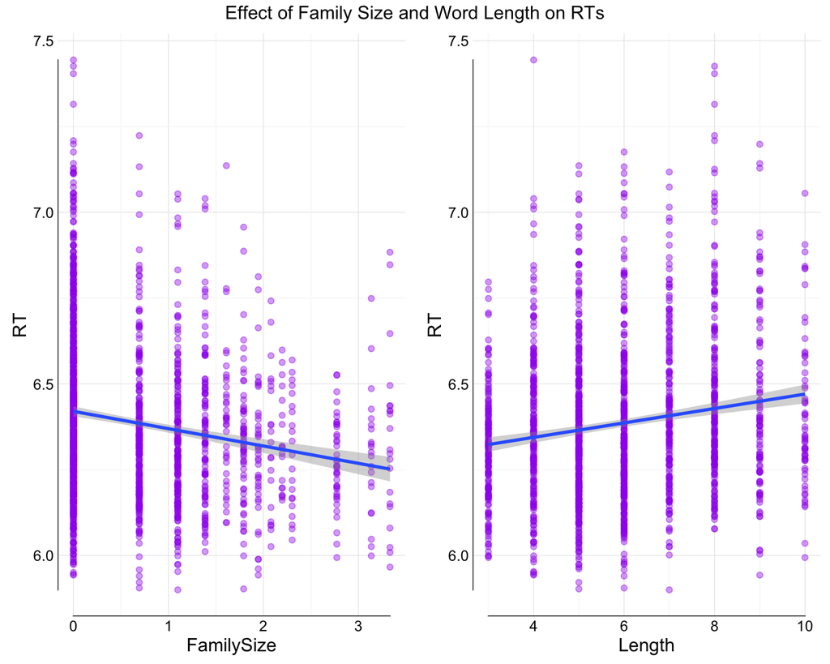

```r
## HINT: to interpret your scatterplots, it might be useful to
## read the documentation of the 'lexdec' dataset to understand
## what FamilySize and Length are measuring.
help(lexdec)
```

# Final questions or comments?